# Статистические методы в биоинформатике

## Домашнее задание 1

**Правила:**

- Дедлайн **17 марта 23:59**.
- Выполненную работу нужно отправить на почту `mipt.stats@yandex.ru`, указав тему письма `"[smb] Фамилия Имя - задание 1"`. Квадратные скобки обязательны. Если письмо дошло, придет ответ от автоответчика.
- Прислать нужно ноутбук и его pdf-версию (без архивов).
- Для выполнения задания используйте этот ноутбук в качествие основы, ничего не удаляя из него.
- Никакой код из данного задания при проверке запускаться не будет.

### Теоретическая часть (15 баллов)

Каждая задача стоит **5 баллов**.

**Задача 1.** Дана выборка $X_1, ..., X_n$ из нормального распределения $\mathcal{N}(a, \sigma^2)$. Найдите оценку максимального правдоподобия параметра $\theta = (a, \sigma)$.

**Задача 2.** Дана выборка $X_1, ..., X_n$ из категориального распределения, то есть распределение на множестве $\{a_1, ..., a_k\}$, причем $\mathsf{P}(X_i = a_j) = p_j$. Найдите оценку максимального правдоподобия параметра $\theta = (p_1, ..., p_k)$.

**Задача 3.** Дана выборка $X_1, ..., X_n$ из пуассоновского распределения $Pois(\theta)$, то есть $\mathsf{P}(X_i = k) = \frac{\theta^k}{k!}e^{-\lambda}$. Найдите оценку максимального правдоподобия параметра $\theta$.

## Задача 1

$X = (X_1, \ldots, X_n)$

$p_i(X, \theta) = \frac{1}{\sigma\sqrt{2\pi}}e^{-\frac{(x_i-a)^2}{2\sigma^2}}$

$L(X, \theta) = \prod\limits_{i=1}^n p_i(\theta) = \prod\limits_{i=1}^n \frac{1}{\sigma\sqrt{2\pi}}e^{-\frac{(x_i-a)^2}{2\sigma^2}}$

$\ln L(X, \theta) = Const - n\ln\sigma - \sum\limits_{i=1}^n \frac{(x_i - a)^2}{2\sigma^2}$ - непр. диф. по $a$, $\sigma > 0$

$\frac{\partial\ln L(X, \theta)}{\partial a} = \sum\limits_{i=1}^n\frac{2(x_i-a)}{2\sigma^2} = \frac{-na + \sum\limits_{i=1}^n x_i}{\sigma^2} = 0 \Rightarrow a = \overline{x}$

$\frac{\partial\ln L(X, \theta)}{\partial \sigma} = -\frac{n}{\sigma} + \frac{\sum\limits_{i=1}^n (x_i - a)^2}{\sigma^3} = 0 \Rightarrow \sigma^2 = \frac{\sum\limits_{i=1}^n (x_i - a)^2}{n} = \overline{(x-a)^2} = \overline{(x-\overline{x})^2} = \overline{x^2-2x\overline{x}+\overline{x}^2} = \overline{x^2} - \overline{x}^2$, т. к. $\overline{x\overline{x}} = \overline{x}^2$

Проверим полож. определенность гессиана:

$\frac{\partial^2\ln L(X, \theta)}{\partial a^2} = -\frac{n}{\sigma^2} < 0$

$\frac{\partial^2\ln L(X, \theta)}{\partial a \partial\sigma} = 0$ при выбранной $a$

$\frac{\partial^2\ln L(X, \theta)}{\partial \sigma^2} = -2n\sigma^2 < 0$

То есть $\hat{a} = \overline{x}$, $\hat{\sigma} = \sqrt{\overline{(x-\overline{x})^2}} = \sqrt{\overline{x^2} - \overline{x}^2}$ - действительно оценки максимального правдоподобия

## Задача 2

$\sum\limits_{j=1}^k p_j = 1$

$L(X, \theta) = \prod\limits_{i=1}^n \prod\limits_{j=1}^k p_j^{I\{x_i = a_j\}} $

$\ln L(X, \theta) = \sum\limits_{i=1}^n \sum\limits_{j=1}^k I\{x_i = a_j\}\ln p_j = \sum\limits_{j=1}^k \#\{x_i|x_i = a_j\}\ln p_j \rightarrow \max\limits_{p_j: \sum\limits_{j=1}^k p_j = 1}, \sum\limits_{j=1}^k \#\{x_i|x_i = a_j\} = n$

Заменим $p_k$ на $1 - \sum\limits_{j=1}^{k-1} p_j$

Для $j=\overline{1,\ldots,k-1} \Rightarrow \frac{\partial\ln L(X, \theta)}{\partial p_j} = \frac{\#\{x_i| x_i = a_j\}}{p_j} - \frac{\#\{x_i| x_i = a_k\}}{1 - \sum\limits_{j=1}^{k-1} p_j} = \frac{\#\{x_i| x_i = a_j\}}{p_j} - \frac{\#\{x_i| x_i = a_k\}}{p_k}$

Чтобы добиться равенства всех этих производных нулю, нужно взять $\hat{p_j} = \frac{\#\{x_i| x_i = a_j\}}{n}$ (других решений нет, т.к. соотношения вероятностей и их общая сумма фиксированы)

Гессиан будет диагонален, на диагонали будут стоять $-\frac{\#\{x_i|x_i = a_j\}}{p_j^2} = -\frac{1}{p_j}$, так что это действительно максимум функции правдоподобия

## Задача 3

$L(X, \theta) = \prod\limits_{i=1}^n \frac{\theta^{x_i} e^{-\theta}}{x_k!} = \frac{e^{-n\theta}\theta^{\Sigma x_j}}{x_1!\ldots x_n!}$

$\ln L(X, \theta) = \sum\limits_{i=1}^n x_i \ln\theta - n\theta - \sum\limits_{i=1}^n \ln x_i!$ - непр. диф по $\theta$ при $\theta > 0$

$\frac{\partial\ln L(X, \theta)}{\partial\theta} = \frac{\sum\limits_{i=1}^n x_i}{\theta} - n = 0 \Rightarrow \hat{\theta} = \frac{\sum\limits_{i=1}^n x_i}{n} = \overline{x} \ge 0$

$\frac{\partial^2\ln L(X, \theta)}{\partial\theta^2} = -\frac{n^2}{\sum\limits_{i=1}^n x_i }< 0$ (т.к. $x_i \ge 0$)

(вырожденный случай, если все $x_i$ равны 0, но тогда $\ln L(X, \theta) = - n\theta$ и получается тот же ответ, максимальность $\theta$ в нуле очевидна)

### Практическая часть (30 баллов)

Сначала импортируем некоторые библиотеки. Если некоторые из них не установлены, установите их командой

`pip install имя_библиотеки`

Библиотека `Bio` устанавливается с помощью

`pip install biopython`

```python
import pandas as pd
import numpy as np
import matplotlib.pyplot as plt
from Bio import SeqIO
%matplotlib inline
```

Загрузите выданные данные с помощью приведенного ниже кода. Вы будете работать с двумя датасетами. Один из них содержит данные об экспрессии генов с сайта gtexportal.org, Genotype-Tissue Expression -- публичного атласа экспресси генов, содержащим экспрессию генов более чем 50 тканей от 1000 пациентов, а так же их генотип. Другой датасет содержит данные о последовательности энхансеров позвоночных. Тема изучения и предсказания энхансеров, а так же их таргета -- важный аспект современной биоинформатики.

```python
gene_counts = pd.read_csv('GTEx_gene_reads.trunc.gct',
                         sep='\t',index_col=0)
records = list(SeqIO.parse("Liver.fasta", "fasta"))
samples_annotation = pd.read_csv('samples_annotation.tsv',
                                sep='\t')
```

Посмотрим на начало таблиц:

```python
gene_counts.head()
```

|  | 0 | 1 | 2 | 3 | 4 | 5 |
| --- | --- | --- | --- | --- | --- | --- |
| Name | ENSG00000237613.2 | ENSG00000183114.6 | ENSG00000060718.14 | ENSG00000184599.9 | ENSG00000135842.12 | ENSG00000114270.11 |
| Description | FAM138A | FAM43B | COL11A1 | FAM19A3 | FAM129A | COL7A1 |
| GTEX-1117F-0226-SM-5GZZ7 | 1 | 27 | 652 | 0 | 5663 | 857 |
| GTEX-111CU-1826-SM-5GZYN | 0 | 43 | 52 | 2 | 1869 | 280 |
| GTEX-111FC-0226-SM-5N9B8 | 1 | 93 | 140 | 4 | 12268 | 1284 |

```python
samples_annotation.head()
```

|  | SAMPID | SMATSSCR | SMCENTER | SMPTHNTS | SMRIN | SMTS | SMTSD | SMUBRID | SMTSISCH | SMTSPAX | ... | SME1ANTI | SMSPLTRD | SMBSMMRT | SME1SNSE | SME1PCTS | SMRRNART | SME1MPRT | SMNUM5CD | SMDPMPRT | SME2PCTS |
| --- | --- | --- | --- | --- | --- | --- | --- | --- | --- | --- | --- | --- | --- | --- | --- | --- | --- | --- | --- | --- | --- |
| 0 | GTEX-1117F-0226-SM-5GZZ7 | 0.0 | B1 | 2 pieces, ~15% vessel stroma, rep delineated | 6.8 | Adipose Tissue | Adipose - Subcutaneous | 0002190 | 1214.0 | 1125.0 | ... | 14579275.0 | 12025354.0 | 0.003164 | 14634407.0 | 50.094357 | 0.003102 | 0.992826 | NaN | 0.0 | 50.126280 |
| 1 | GTEX-1117F-0426-SM-5EGHI | 0.0 | B1 | 2 pieces, !5% fibrous connective tissue, delin... | 7.1 | Muscle | Muscle - Skeletal | 0011907 | 1220.0 | 1119.0 | ... | 13134349.0 | 11578874.0 | 0.003991 | 13307871.0 | 50.328114 | 0.006991 | 0.994212 | NaN | 0.0 | 49.905170 |
| 2 | GTEX-1117F-0526-SM-5EGHJ | 0.0 | B1 | 2 pieces, clean, Monckebeg medial sclerosis, r... | 8.0 | Blood Vessel | Artery - Tibial | 0007610 | 1221.0 | 1120.0 | ... | 13169835.0 | 11015113.0 | 0.004285 | 13160068.0 | 49.981450 | 0.002867 | 0.992711 | NaN | 0.0 | 50.227848 |
| 3 | GTEX-1117F-0626-SM-5N9CS | 1.0 | B1 | 2 pieces, up to 4mm aderent fat/nerve/vessel, ... | 6.9 | Blood Vessel | Artery - Coronary | 0001621 | 1243.0 | 1098.0 | ... | 15148343.0 | 11624467.0 | 0.003379 | 15282444.0 | 50.220333 | 0.005335 | 0.991175 | NaN | 0.0 | 50.025043 |
| 4 | GTEX-1117F-0726-SM-5GIEN | 1.0 | B1 | 2 pieces, no abnormalities | 6.3 | Heart | Heart - Atrial Appendage | 0006631 | 1244.0 | 1097.0 | ... | 13583226.0 | 9262806.0 | 0.003451 | 13745609.0 | 50.297090 | 0.030579 | 0.994478 | NaN | 0.0 | 49.929870 |

5 rows × 63 columns

**0.** С помощью функции `plt.hist` постройте общую гистограмму экспрессии для гена FAM129A из таблицы `gene_counts` для всех `SAMPID`, представленных в `samples_annotation`. Для этого выберите нужные строчки (в данном случаем можно по индексу образцов `SAMPID`) и столбец, где `Description==FAM129A`.

На какое распределение похожа гистограмма?

```python
a = gene_counts.loc["Description"] == "FAM129A"
ind = a.index[a == True].tolist()
h = []
for sampid in samples_annotation["SAMPID"]:
    h.append(gene_counts[ind].loc[sampid][0])
results = list(map(float, h))
```

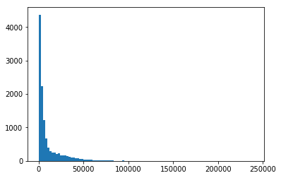

```python
plt.hist(results, bins=100)
plt.show()
```

Распределение похоже на экспоненциальное, $p(x, \theta) = \theta e^{-\theta x}, \ln L = n\ln\theta-\theta n \overline{x}$

**1.** Скорее всего у вас получилось некоторое распределение, параметризованное параметром $\theta$. Найдите оценку максимального правдоподобия этого параметра, построив график логарифмической функции правдоподобия и взяв по нему точку максимума. Чему она равна? Решите данную задачу теоретически и сравните ответ.

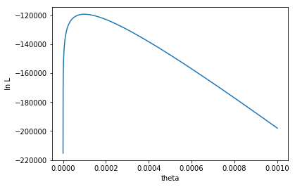

```python
n = len(results)
x_ = np.mean(results)
start = 1.0e-8
end = 1.0e-3
steps = 100000
x = np.linspace(start, end, steps)
dx = (end-start)/steps
y = []
for el in x:
    s = n*np.log(el)-el*n*x_
    y.append(s)
plt.plot(x, y)
plt.xlabel("theta")
plt.ylabel("ln L")
plt.show()
```

```python
i = np.argmax(y)
print("theta = " + str(x[i]) + " +- " + str(dx))
```

```
theta = 9.965999999999999e-05 +- 9.9999e-09
```

$L(x, \theta) = \prod\limits_{i=1}^n \theta e^{-\theta x_i}$

$\ln L(x, \theta) = n \ln\theta -\theta\sum\limits_{i=1}^n x_i$

$\frac{\partial \ln L}{\partial x} = \frac{n}{\theta} - \sum\limits_{i=1}^n x_i$

$\hat{\theta} = \frac{1}{\overline{x}}$

Найдем эту оценку по выборке

```python
1/np.mean(results)
```

```
9.965639943424018e-05
```

Видим, что оценки совпадают с большой точностью, что может указывать на правильность гипотезы о виде распределения (но не доказывает полностью)

**2.1.** Посчитайте, сколько различных тканей представлено в колонке `SMTSD` таблицы `samples_annotation`. Сколько образцов из артерии большеберцовой кости (`Artery - Tibial`) и легкого (`Lung`)? При выполнении задания может помочь метод `value_counts()`, вызванный у столбца таблицы.

```python
print("Totally tissues " + str(len(samples_annotation["SMTSD"].value_counts())))
print("Artery - Tibial " + str(samples_annotation["SMTSD"].value_counts().loc["Artery - Tibial"]))
print("Lung " + str(samples_annotation["SMTSD"].value_counts().loc["Lung"]))
```

```
Totally tissues 53
Artery - Tibial 441
Lung 427
```

**2.2.** Постройте гистограммы отдельно для артерии и легкого. Что можно о них сказать?

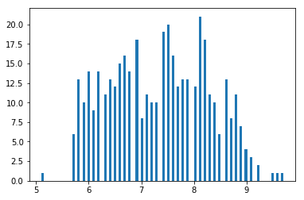

```python
lung = samples_annotation["SMTSD"] == "Lung"
ind_lung = lung.index[lung == True].tolist()
data_lung = []
for el in ind_lung:
    data_lung.append(samples_annotation.iloc[el, int(ind[0])])
plt.hist(data_lung, bins=100)
plt.show()
```

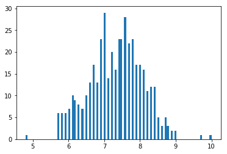

```python
art = samples_annotation["SMTSD"] == "Artery - Tibial"
ind_art = lung.index[art == True].tolist()
data_art = []
for el in ind_art:
    data_art.append(samples_annotation.iloc[el, int(ind[0])])
plt.hist(data_art, bins=100)
plt.show()
```

Для таких знаем теоретически, что $\theta = (a, \sigma)$ и $\hat{a} = \overline{x}, \hat{\sigma}^2 = \overline{(x-\overline{x})^2}$

**2.3.** Посчитайте оценку $\theta$ как в пункте 1 отдельно для двух рассматриваемых выше тканей. Что о них можно сказать?

```python
mean_lung = np.mean(data_lung)
s = 0
for el in data_lung:
    s += (el - mean_lung)**2
sigma_lung = np.sqrt(s/n)
print("Lung: a = {a}, sigma = {sigma}".format(a=mean_lung, sigma=sigma_lung))

mean_art = np.mean(data_art)
s = 0
for el in data_art:
    s += (el - mean_art)**2
sigma_art = np.sqrt(s/n)
print("Artery: a = {a}, sigma = {sigma}".format(a=mean_art, sigma=sigma_art))
```

```
Lung: a = 7.34028103044, sigma = 0.179002857866
Artery: a = 7.31678004535, sigma = 0.146997042016
```